# Peer Assessment 1

Peer assessment 1 assignment for Coursera course Reproducible Research.

## Introduction

> It is now possible to collect a large amount of data about personal movement using activity monitoring devices such as a [Fitbit](http://www.fitbit.com), [Nike Fuelband](http://www.nike.com/us/en_us/c/nikeplus-fuelband), or [Jawbone Up](https://jawbone.com/up). These type of devices are part of the “quantified self” movement – a group of enthusiasts who take measurements about themselves regularly to improve their health, to find patterns in their behavior, or because they are tech geeks. But these data remain under-utilized both because the raw data are hard to obtain and there is a lack of statistical methods and software for processing and interpreting the data.

> This assignment makes use of data from a personal activity monitoring device. This device collects data at 5 minute intervals through out the day. The data consists of two months of data from an anonymous individual collected during the months of October and November, 2012 and include the number of steps taken in 5 minute intervals each day.

## Data

> The data for this assignment can be downloaded from the course web site:
> - Dataset: [Activity monitoring data](https://d396qusza40orc.cloudfront.net/repdata%2Fdata%2Factivity.zip) [52K]

> The variables included in this dataset are:
> - **steps**: Number of steps taking in a 5-minute interval (missing values are coded as `NA`)
> - **date**: The date on which the measurement was taken in YYYY-MM-DD format
> - **interval**: Identifier for the 5-minute interval in which measurement was taken

> The dataset is stored in a comma-separated-value (CSV) file and there are a total of 17,568 observations in this dataset.

## Assignment

> This assignment will be described in multiple parts. You will need to write a report that answers the questions detailed below. Ultimately, you will need to complete the entire assignment in a **single R markdown** document that can be processed by **knitr** and be transformed into an HTML file.

> Throughout your report make sure you always include the code that you used to generate the output you present. When writing code chunks in the R markdown document, always use `echo = TRUE` so that someone else will be able to read the code. **This assignment will be evaluated via peer assessment so it is essential that your peer evaluators be able to review the code for your analysis**.

> For the plotting aspects of this assignment, feel free to use any plotting system in R (i.e., base, lattice, ggplot2)

> Fork/clone the [GitHub repository created for this assignment](http://github.com/rdpeng/RepData_PeerAssessment1). You will submit this assignment by pushing your completed files into your forked repository on GitHub. The assignment submission will consist of the URL to your GitHub repository and the SHA-1 commit ID for your repository state.

> NOTE: The GitHub repository also contains the dataset for the assignment so you do not have to download the data separately.

Load packages.

```r
packages <- c("data.table", "ggplot2", "xtable")
sapply(packages, require, character.only = TRUE, quietly = TRUE)
```

```
## data.table    ggplot2     xtable
##       TRUE       TRUE       TRUE
```

### Loading and preprocessing the data

> Show any code that is needed to
> 1. Load the data (i.e. `read.csv()`)
> 2. Process/transform the data (if necessary) into a format suitable for your analysis

Unzip the data file.

```r
executable <- file.path("C:", "Program Files (x86)", "7-Zip", "7z.exe")
parameters <- "x"
f <- file.path(getwd(), "activity.zip")
switch <- "-aoa"
cmd <- paste(paste0("\"", executable, "\""), parameters, paste0("\"", f, "\""),
    switch)
cmd
system(cmd)
```

Read the CSV file. Convert the data frame to a data table using the [`data.table`](http://cran.r-project.org/web/packages/data.table/index.html) package.

```r
dt <- read.csv(file.path(getwd(), "activity.csv"))
dt <- data.table(dt)
setkey(dt, date, interval)
```

Verify that the number of rows in the dataset is the expected value of 17,568.

```r
message(sprintf("Is the number of rows in the dataset 17,568? %s", nrow(dt) ==
    17568))
```

```
## Is the number of rows in the dataset 17,568? TRUE
```

Convert the `date` variable to a date class. And look at the structure of the dataset.

```r
dt <- dt[, `:=`(date, as.Date(date))]
str(dt)
```

```
## Classes 'data.table' and 'data.frame':   17568 obs. of  3 variables:
##  $ steps   : int  NA NA NA NA NA NA NA NA NA NA ...
##  $ date    : Date, format: "2012-10-01" "2012-10-01" ...
##  $ interval: int  0 5 10 15 20 25 30 35 40 45 ...
##  - attr(*, ".internal.selfref")=<externalptr>
```

### What is mean total number of steps taken per day?

> For this part of the assignment, you can ignore the missing values in the dataset.
> 1. Make a histogram of the total number of steps taken each day
> 2. Calculate and report the **mean** and **median** total number of steps taken per day

Aggregate the number of steps taken each day. Ignore the missing values.

```r
dtDaily <- dt[, list(sumSteps = sum(steps, na.rm = TRUE)), date]
```

Plot a histogram of the total number of steps taken each day.

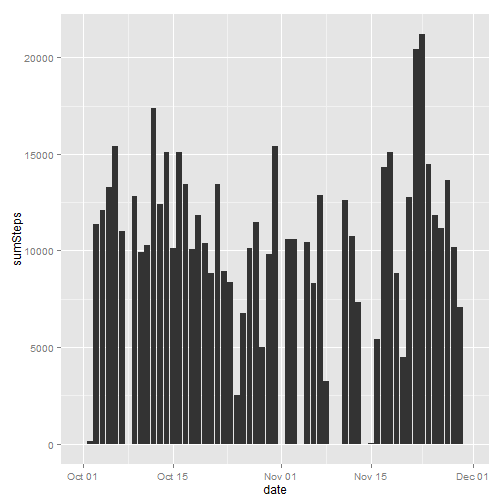

```r
ggplot(dtDaily, aes(x = date, y = sumSteps)) + geom_histogram(stat = "identity")
```

Calculate the mean and median total number of steps taken per day.

```r
print(xtable(dtDaily[, list(mean = mean(sumSteps), median = median(sumSteps))]),
    type = "html", include.rownames = FALSE)
```

| mean | median |
| --- | --- |
| 9354.23 | 10395 |

### What is the average daily activity pattern?

Aggregate the average number of steps taken by 5-minute interval.

```r
dtIntervals <- dt[, list(meanSteps = mean(steps, na.rm = TRUE)), interval]
```

Plot a time series of the 5-minute interval and the average number of steps taken across all days.

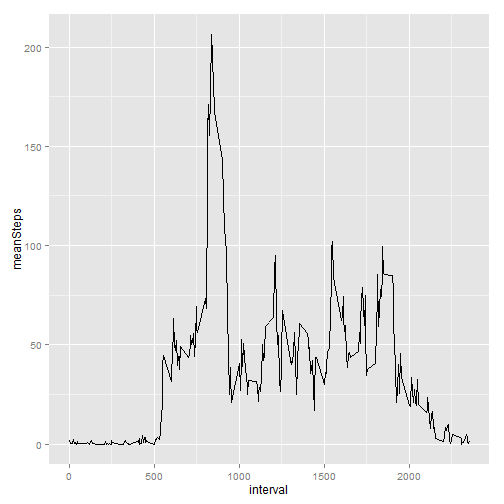

```r
ggplot(dtIntervals, aes(x = interval, y = meanSteps)) + geom_line()
```

### Imputing missing values

> Note that there are a number of days/intervals where there are missing values (coded as `NA`). The presence of missing days may introduce bias into some calculations or summaries of the data.
> 1. Calculate and report the total number of missing values in the dataset (i.e. the total number of rows with `NA`s)
> 2. Devise a strategy for filling in all of the missing values in the dataset. The strategy does not need to be sophisticated. For example, you could use the mean/median for that day, or the mean for that 5-minute interval, etc.
> 3. Create a new dataset that is equal to the original dataset but with the missing data filled in.
> 4. Make a histogram of the total number of steps taken each day and Calculate and report the **mean** and **median** total number of steps taken per day. Do these values differ from the estimates from the first part of the assignment? What is the impact of imputing missing data on the estimates of the total daily number of steps?

Calculate the total number of missing values.

```r
dt <- dt[, `:=`(isStepsMissing, is.na(steps))]
print(xtable(dt[, .N, isStepsMissing]), type = "html", include.rownames = FALSE)
```

| isStepsMissing | N |
| --- | --- |
| TRUE | 2304 |
| FALSE | 15264 |

Fit a linear model for the number of steps taken using the 5-minute interval as the predictor. Specify the 5-minute interval predictor as a factor class variable. This model estimates the mean number of steps taken for each 5-minute interval. Use the predicted values from this model to impute missing values; call this variable `stepsImputed`.

```r
M <- lm(steps ~ factor(interval), data = dt, na.action = "na.exclude")
dt <- dt[, `:=`(stepsImputed, steps)]
dt$stepsImputed[dt$isStepsMissing] <- predict(M, newdata = dt)[dt$isStepsMissing]
```

Verify that there are no missing values for `stepsImputed`.

```r
print(xtable(dt[, .N, list(isMissing = is.na(stepsImputed))]), type = "html",
    include.rownames = FALSE)
```

| isMissing | N |
| --- | --- |
| FALSE | 17568 |

Verify that missingness is complete for an entire day.

```r
dtMissingness <- dt[, list(countMissing = sum(isStepsMissing), countRecords = .N,
    propMissing = sum(isStepsMissing/.N)), date]
dtMissingness[countMissing > 0]
```

```
##          date countMissing countRecords propMissing
## 1: 2012-10-01          288          288           1
## 2: 2012-10-08          288          288           1
## 3: 2012-11-01          288          288           1
## 4: 2012-11-04          288          288           1
## 5: 2012-11-09          288          288           1
## 6: 2012-11-10          288          288           1
## 7: 2012-11-14          288          288           1
## 8: 2012-11-30          288          288           1
```

#### After imputation of missing values

Aggregate the number of steps taken each day.

```r
dtDaily <- dt[, list(sumSteps = sum(steps, na.rm = TRUE), sumStepsImputed = sum(stepsImputed),
    isImputed = sum(isStepsMissing) > 0), date]
dtDaily
```

```
##           date sumSteps sumStepsImputed isImputed
##  1: 2012-10-01        0           10766      TRUE
##  2: 2012-10-02      126             126     FALSE
##  3: 2012-10-03    11352           11352     FALSE
##  4: 2012-10-04    12116           12116     FALSE
##  5: 2012-10-05    13294           13294     FALSE
##  6: 2012-10-06    15420           15420     FALSE
##  7: 2012-10-07    11015           11015     FALSE
##  8: 2012-10-08        0           10766      TRUE
##  9: 2012-10-09    12811           12811     FALSE
## 10: 2012-10-10     9900            9900     FALSE
## 11: 2012-10-11    10304           10304     FALSE
## 12: 2012-10-12    17382           17382     FALSE
## 13: 2012-10-13    12426           12426     FALSE
## 14: 2012-10-14    15098           15098     FALSE
```

[output cut: 48 more lines]

Plot a histogram of the total number of steps taken each day. Indicate dates with imputed values using a different color.

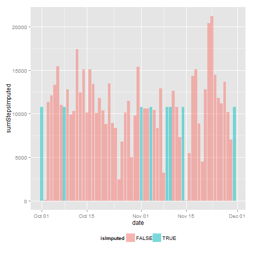

```r
ggplot(dtDaily, aes(x = date, y = sumStepsImputed, fill = isImputed)) + geom_histogram(stat = "identity",
    alpha = 1/2) + theme(legend.position = "bottom")
```

Calculate the mean and median total number of steps taken per day.

```r
print(xtable(dtDaily[, list(meanBefore = mean(sumSteps), meanImputed = mean(sumStepsImputed),
    medianBefore = median(sumSteps), medianImputed = median(sumStepsImputed))]),
    type = "html", include.rownames = FALSE)
```

| meanBefore | meanImputed | medianBefore | medianImputed |
| --- | --- | --- | --- |
| 9354.23 | 10766.19 | 10395 | 10766.19 |

### Are there differences in activity patterns between weekdays and weekends?

Create a new factor variable in the dataset with two levels – “weekday” and “weekend” indicating whether a given date is a weekday or weekend day. Use this solution to [collapse the factor values](http://stackoverflow.com/a/9053619) for day of week. Verify that `dayOfWeek` and `dayType` are factor class variables.

```r
levels <- c("Sunday", "Monday", "Tuesday", "Wednesday", "Thursday", "Friday",
    "Saturday")
newLevels <- c("Weekend", rep("Weekday", 5), "Weekend")
dt <- dt[, `:=`(dayOfWeek, factor(weekdays(date), levels = levels))]
dt <- dt[, `:=`(dayType, factor(newLevels[dayOfWeek]))]
dt[, .N, list(dayType, dayOfWeek)]
```

```
##    dayType dayOfWeek    N
## 1: Weekday    Monday 2592
## 2: Weekday   Tuesday 2592
## 3: Weekday Wednesday 2592
## 4: Weekday  Thursday 2592
## 5: Weekday    Friday 2592
## 6: Weekend  Saturday 2304
## 7: Weekend    Sunday 2304
```

```r
message(sprintf("Is dayOfWeek a factor? %s. Is dayType a factor? %s", is.factor(dt$dayOfWeek),
    is.factor(dt$dayType)))
```

```
## Is dayOfWeek a factor? TRUE. Is dayType a factor? TRUE
```

Aggregate the average number of steps taken by 5-minute interval. Use the imputed values in the `stepsImputed` variable.

```r
dtIntervals <- dt[, list(meanSteps = mean(stepsImputed, na.rm = TRUE)), list(dayType,
    interval)]
```

Plot two time series (one for weekdays and the other for weekends) of the 5-minute intervals and average number of steps taken (imputed values).

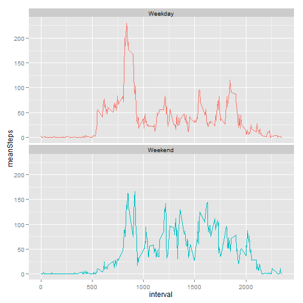

```r
ggplot(dtIntervals, aes(x = interval, y = meanSteps, color = dayType)) + geom_line() +
    facet_wrap(~dayType, nrow = 2) + theme(legend.position = "none")
```

It's a bit hard to discern any differences. So overlay the time series on a single plot instead of using a panel plot.

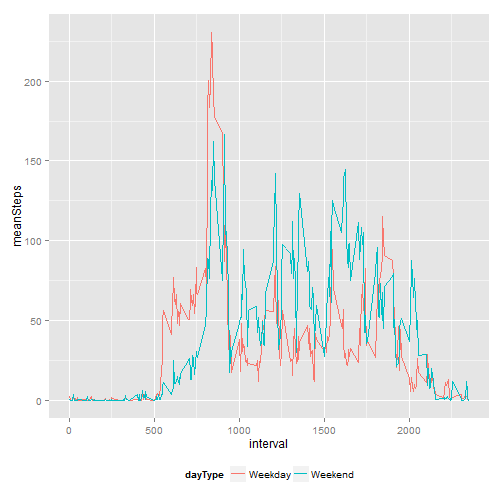

```r
ggplot(dtIntervals, aes(x = interval, y = meanSteps, color = dayType)) + geom_line() +
    theme(legend.position = "bottom")
```